# R Notebook

## Exercise 1. Ice Cream

**a)**

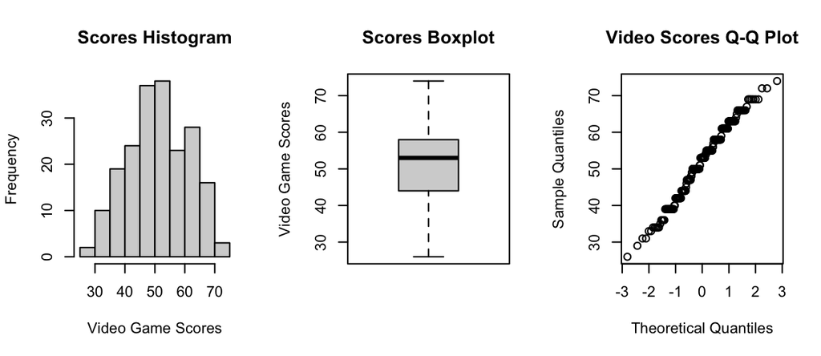

```r
#Read in the data and extract the relevant column
ice_cream=read.csv("data/Ice_cream.csv",header=TRUE)
video=ice_cream$video

#Create relevant figures to assess distribution normality
par(mfrow=c(1,3))
hist(video, xlab="Video Game Scores", main="Scores Histogram"); boxplot(video, ylab="Video Game Scores", main="Scores Boxplot"); qqnorm(video, main="Video Scores Q-Q Plot")
```

The data for the video games scores appears to be close to normally distributed. Both the histogram and boxplot indicate that the scores are unimodal and moderately evenly distributed about the mean. The qq-plot confirms this as the data points are nearly linear. Hence, any testing or methods used with a normality assumption are justified.

```r
#Constructing a bounded 97% confidence interval
video_mean = mean(video)
video_se = sd(video)/sqrt(length(video))
alpha = 0.03
degrees_freedom = length(video) - 1
t_score = qt(p=alpha/2, df=degrees_freedom, lower.tail=F)
margin_error = video_se * t_score
lower_bound = video_mean - margin_error
upper_bound = video_mean + margin_error
```

The bounds for the 97% confidence interval are [50.3197, 53.3803].

```r
#Calculating the number of samples needed for a confidence interval of at most length 3
desired_margin_error = 1.5
z_score = qnorm(0.985)
num_samples = ((z_score*sd(video))/desired_margin_error)^2
```

The number of samples needed for a confidence interval of at most length 3 is at least 206.

```r
#Creating a bootstrapped 97% confidence interval
B = 1000
Tstar = numeric(B)
for (i in 1:B) {
  Xstar = sample(video, replace = TRUE)
  Tstar[i] = mean(Xstar)
}
Tstar015 = quantile(Tstar, 0.015)  #Lower bound
Tstar985 = quantile(Tstar, 0.985)  #Upper bound

confidence_interval = c(2*mean(video) - Tstar985, 2*mean(video) - Tstar015)
```

Our bootstrapped confidence interval is (50.4298, 53.4051). We notice that this confidence interval is minutely smaller than the bounded confidence interval above. However, they are extremely similar. Since the data is already relatively normally distributed, the original confidence interval likely provides a good enough estimate and bootstrapping is unnecessary in this case.

**b)**

```r
#First t-test when mu_0 = 50
t.test(video, mu=50, alt="g")
```

```
    One Sample t-test

data:  video
t = 2.6425, df = 199, p-value = 0.004442
alternative hypothesis: true mean is greater than 50
95 percent confidence interval:
 50.69305      Inf
sample estimates:
mean of x
    51.85
```

```r
#Second t-test when mu_0 = 51
t.test(video, mu=51, alt="g")
```

```
    One Sample t-test

data:  video
t = 1.2141, df = 199, p-value = 0.1131
alternative hypothesis: true mean is greater than 51
95 percent confidence interval:
 50.69305      Inf
sample estimates:
mean of x
    51.85
```

**c)**

```r
binom.test(sum(video>50), length(video), p=0.5, alt="g")
```

```
    Exact binomial test

data:  sum(video > 50) and length(video)
number of successes = 108, number of trials = 200, p-value = 0.1444
alternative hypothesis: true probability of success is greater than 0.5
95 percent confidence interval:
 0.4793777 1.0000000
sample estimates:
probability of success
                  0.54
```

```r
wilcox.test(video, mu=50, alt="g")
```

```
    Wilcoxon signed rank test with continuity correction

data:  video
V = 9835.5, p-value = 0.005107
alternative hypothesis: true location is greater than 50
```

```r
binom.test(sum(video<42), length(video), p=0.25, alt="l")
```

```
    Exact binomial test

data:  sum(video < 42) and length(video)
number of successes = 31, number of trials = 200, p-value = 0.0007891
alternative hypothesis: true probability of success is less than 0.25
95 percent confidence interval:
 0.0000000 0.2034054
sample estimates:
probability of success
                 0.155
```

First, we conduct a sign test to determine whether or not the median is greater than 50. Our null hypothesis is that the median is less than or equal to fifty, while our alternative hypothesis is that it is greater than 50. Since our resulting p-value is greater than 0.05, we do not reject the null hypothesis that the median is less than or equal to 50. This test does not align with out result from part b); however, in this case we are comparing medians and not means. In particular, with the sign test, we are not comparing the actual data values. Therefore, t-test is more sensitive to smaller deviations from the mean and any slight skewness.

Secondly, we conduct a Wilcoxon signed rank test. Since our data is close to normal, we fulfill the requirement of a symmetric distribution. We follow the same hypotheses as the sign test above. However, since our p-value is much less than 0.05, we reject the null hypothesis in favor of the alternative.

To perform a test to check whether the fraction of the scores less than 42 is at most 25%, we can do a modified version of the sign test for medians, but instead compare the lower quartiles. In this case, we have a null hypothesis that the lower quartile is greater than or equal to 42 and an alternative hypothesis that it is less than or equal to 42. Since our p-value is much lower than 0.05, we reject the null hypothesis in favor of the alternative that in fact the fraction of scores less than 42 is at most 25%.

**d)**

```r
n=length(video)
t=min(video)
mus = c()
B=1000; tstar=numeric(B)
for (j in 0:100){
  for (i in 1:B){
  xstar=rnorm(200, mean=j, sd=10)
  tstar[i]=min(xstar)
  }
  pl=sum(tstar<t)/B; pr=sum(tstar>t)/B
  p=2*min(pl,pr)
  if (p >= 0.05){
    mus = c(mus, j)
  }
}
```

The values of $\mu$ for which the null hypothesis is not rejected are 47, 48, 49, 50, 51, 52, 53, 54, 55, 56, 57, 58, 59, 60, 61, 62.

```r
ks_mus = c()
suppressWarnings(for (j in 0:100){
  xstar=rnorm(200, mean=j, sd=10)
  p = ks.test(video, xstar)[[2]]
  if (p >= 0.05){
    ks_mus = c(ks_mus, j)
  }
})
```

The Kolmogorov-Smirnov test is applicable in this case since we have two independent samples: one from our dataset and one from our simulated normal distribution. In this case, we can conduct an experiment similar to that above. By using a Kolmogorov-Smirnov test, the values of $\mu$ for which the null hypothesis is not rejected are 51, 52, 53, 54.

**e)**

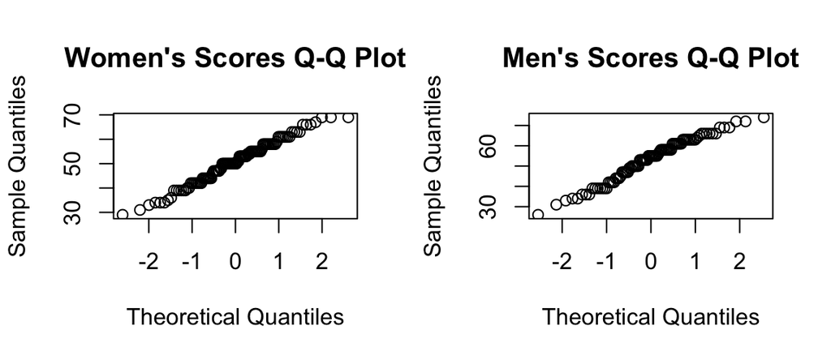

```r
#Extracting the boolean data for scores from women and men
women_scores = ice_cream$video[ice_cream$female == 1]
men_scores = ice_cream$video[ice_cream$female == 0]

par(mfrow=c(1,2))
qqnorm(women_scores, main="Women's Scores Q-Q Plot"); qqnorm(men_scores, main="Men's Scores Q-Q Plot")
```

```r
#Two-sample t-test
t.test(women_scores, men_scores)
```

```
    Welch Two Sample t-test

data:  women_scores and men_scores
t = -1.7847, df = 176.56, p-value = 0.07603
alternative hypothesis: true difference in means is not equal to 0
95 percent confidence interval:
 -5.3350452  0.2680021
sample estimates:
mean of x mean of y
 50.69725  53.23077
```

```r
#Mann-Whitney test
wilcox.test(women_scores, men_scores)
```

```
    Wilcoxon rank sum test with continuity correction

data:  women_scores and men_scores
W = 4171, p-value = 0.05265
alternative hypothesis: true location shift is not equal to 0
```

```r
#Kolmogorov-Smirnov test
ks.test(women_scores, men_scores)
```

```
    Exact two-sample Kolmogorov-Smirnov test

data:  women_scores and men_scores
D = 0.16433, p-value = 0.07148
alternative hypothesis: two-sided
```

**f)**

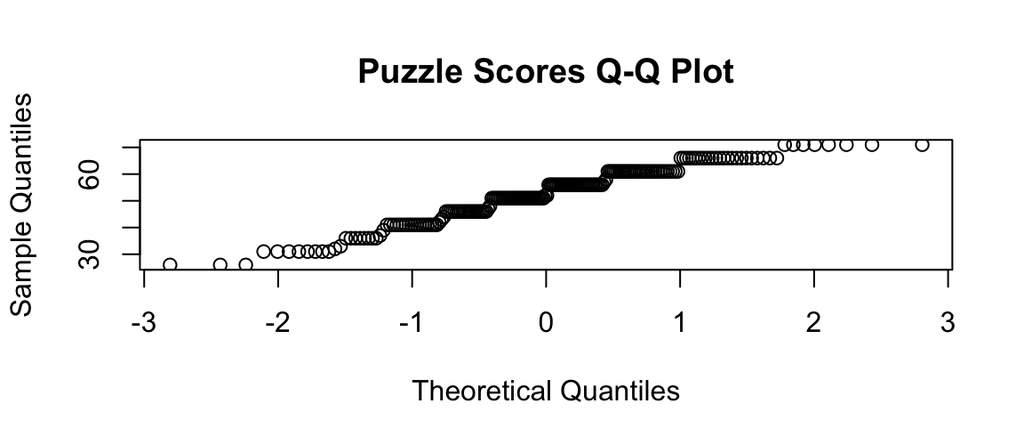

```r
puzzle=ice_cream$puzzle

#Check normality for the puzzle scores
qqnorm(puzzle, main="Puzzle Scores Q-Q Plot")
```

```r
cor.test(video, puzzle, method="spearman")
```

```
    Spearman's rank correlation rho

data:  video and puzzle
S = 692269, p-value = 5.784e-13
alternative hypothesis: true rho is not equal to 0
sample estimates:
      rho
0.4807849
```

To use Pearson’s correlation test, we need to first check the normality assumption for the puzzle score data, since we have already checked the assumption for the video game score data. The data looks more like a step function than a linear function, so the normality assumption is doubtful. It is then safer to use Spearman’s correlation test, which does not assume normality. In this case, the null hypothesis is that the correlation coefficient is equal to 0, i.e. there is no correlation. Since our p-value for the Spearman test is much lower than 0.05, we reject the null hypothesis in favor of the alternative, that there is a significant correlation between the two samples.